# Wasting in Bangladeshi infants aged 6-13 months

Dataset 7: Bangladesh growth monitoring and promotion survey

RSR feasibility analysis

2026-08-03

# Introduction

The data come from a cross-sectional household survey in rural Bangladesh that compared two ways of delivering growth monitoring and promotion (GMP): sessions held at a community clinic (“facility-based”) and sessions held in the community/home (“home-based”). Caregivers of 3038 young children across six upazilas were interviewed and the children were weighed and measured (source paper: PLOS ONE, e0324918). Wasting — weight-for-height more than two standard deviations below the WHO reference median — is the indicator of *acute* undernutrition, carries the highest short-term mortality risk of the three standard indices, and is the one a growth-monitoring programme would hope to detect early.

**Aim.** Among rural Bangladeshi infants aged 6-13 months, we examined which of GMP delivery model, child sex, child age, mother’s age, mother’s schooling, household asset tertile, NGO membership and toilet quality are independently associated with the odds of wasting, mutually adjusting for the others.

This is a *Purpose 3* analysis: several predictors are of interest and the question is which remain associated with the outcome after mutual adjustment.

# Methods

**Data source.** Cross-sectional survey of 3038 caregiver-child pairs in six rural upazilas of Bangladesh. The study sampled 60 community-clinic catchment areas, arranged as matched pairs, one area of each pair receiving facility-based and the other home-based GMP. The file supplied for this catalogue contains one row per child.

*Weight-for-height Z-score is excluded by construction.* The outcome is a deterministic cut of `weight_for_height_z`, so including the parent Z-score would give complete separation. `weight_for_age_z` is also excluded because it is computed from the identical weight measurement, and `height_for_age_z` / `stunted` because they use the same length measurement on the same child.

*Delivery model versus sub-district.* `delivery_model` and `sub_district` are almost the same variable: only 8 of 3038 records (0.3%) sit in a sub-district whose other children received the alternative model. Fitting both together yields variance inflation factors of roughly 96 and 103 and inflates the delivery-model standard error about nine-fold. We kept `delivery_model`, the substantive programme exposure, and excluded `sub_district`; geographic variation between the six upazilas is therefore absorbed into the delivery-model coefficient.

*Near-constant variables dropped.* `mother_occupation` is 97.5% “housewife” and `religion_muslim` is 97.8% Muslim. With only 218 events in this analysis these variables are especially dangerous — the smallest cross-classified cell would contain a handful of children — so both were left out of the main model and are shown in a sensitivity fit in the feasibility notes.

**Statistical analysis.** Logistic regression via `glm(family = binomial)`, justified because the outcome is binary. We fitted a univariable model for each predictor first, then a single multivariable model containing all of them. Predictors were chosen in advance on subject-matter grounds, not by significance. Estimates are reported as odds ratios with 95% confidence intervals; significance threshold 0.05. Model fit is summarised with AIC and the events-per-parameter ratio. Assumptions were checked with `performance::check_model()`. Analysis used R version 4.6.0 (2026-04-24) with tidyverse, gtsummary and performance.

**Missing data.** Complete-case analysis: 3031 of 3038 rows were analysed (7 dropped), of whom 218 were wasted.

# Results

## Sample characteristics

**Table 1. Sample characteristics, by wasting status.**

| **Characteristic** | **N** | **Overall** N = 3,031<sup>1</sup> | **Not wasted** N = 2,813<sup>1</sup> | **Wasted** N = 218<sup>1</sup> |
| --- | --- | --- | --- | --- |
| Growth-monitoring delivery model | 3,031 |  |  |  |
| Facility-based |  | 1,517 (50%) | 1,419 (50%) | 98 (45%) |
| Home-based |  | 1,514 (50%) | 1,394 (50%) | 120 (55%) |
| Child's sex | 3,031 |  |  |  |
| Male |  | 1,544 (51%) | 1,423 (51%) | 121 (56%) |
| Female |  | 1,487 (49%) | 1,390 (49%) | 97 (44%) |
| Child's age (months) | 3,031 | 9.70 (8.50, 11.30) | 9.70 (8.50, 11.20) | 10.20 (8.80, 11.70) |
| Mother's age (years) | 3,031 | 25.0 (21.0, 30.0) | 25.0 (21.0, 30.0) | 26.0 (21.0, 30.0) |
| Mother's schooling (years) | 3,031 | 6.0 (4.0, 9.0) | 6.0 (4.0, 9.0) | 5.0 (3.0, 8.0) |
| Household asset index tertile | 3,031 |  |  |  |
| Lowest |  | 1,022 (34%) | 929 (33%) | 93 (43%) |
| Middle |  | 1,017 (34%) | 944 (34%) | 73 (33%) |
| Highest |  | 992 (33%) | 940 (33%) | 52 (24%) |
| Mother is an NGO member | 3,031 | 1,567 (52%) | 1,449 (52%) | 118 (54%) |
| Improved toilet facility | 3,031 | 2,830 (93%) | 2,628 (93%) | 202 (93%) |

<sup>1</sup> n (%); Median (Q1, Q3)

7.2% of children (218 of 3031) were wasted — far fewer events than for stunting or underweight in the same children, which is both epidemiologically expected and the main statistical constraint on this analysis. Wasted children come somewhat more often from the lowest asset tertile, but the differences across the other predictors in Table 1 are small.

## Exploratory figure

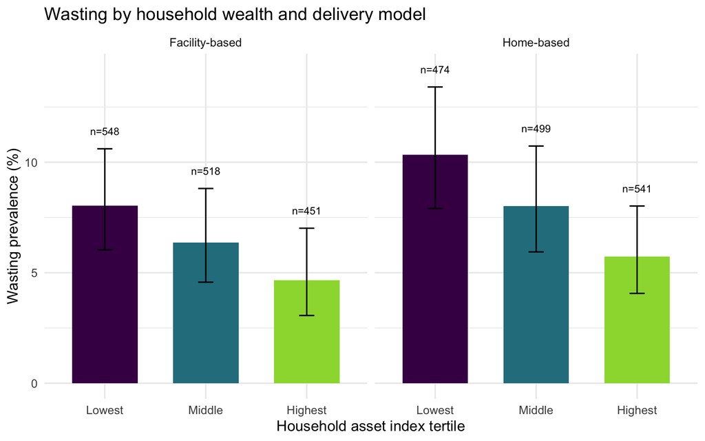

Figure 1. Prevalence of wasting by household asset tertile, separately for the two growth-monitoring delivery models. Error bars are 95% Wilson confidence intervals; numbers above the bars are group sizes. Note the wide intervals, a direct consequence of the small number of wasted children.

Wasting prevalence is lower in the highest asset tertile in both arms, but the confidence intervals are wide and overlap substantially, so the wealth gradient here is much less clear-cut than it is for stunting or underweight.

## Univariable models

| **Characteristic** | **N** | **OR** | **95% CI** | **p-value** |
| --- | --- | --- | --- | --- |
| Growth-monitoring delivery model | 3,031 |  |  |  |
| Facility-based |  | — | — |  |
| Home-based |  | 1.25 | 0.95, 1.65 | 0.12 |
| Child's sex | 3,031 |  |  |  |
| Male |  | — | — |  |
| Female |  | 0.82 | 0.62, 1.08 | 0.2 |
| Child's age (months) | 3,031 | 1.15 | 1.06, 1.24 | <0.001 |
| Mother's age (years) | 3,031 | 1.02 | 0.99, 1.04 | 0.2 |
| Mother's schooling (years) | 3,031 | 0.96 | 0.92, 1.00 | 0.029 |
| Household asset index tertile | 3,031 |  |  |  |
| Lowest |  | — | — |  |
| Middle |  | 0.77 | 0.56, 1.06 | 0.11 |
| Highest |  | 0.55 | 0.39, 0.78 | <0.001 |
| Mother is an NGO member | 3,031 |  |  |  |
| No |  | — | — |  |
| Yes |  | 1.11 | 0.84, 1.47 | 0.5 |
| Improved toilet facility | 3,031 |  |  |  |
| No |  | — | — |  |
| Yes |  | 0.89 | 0.54, 1.57 | 0.7 |

Abbreviations: CI = Confidence Interval, OR = Odds Ratio

Only three predictors reach significance unadjusted. Children in the highest asset tertile have OR 0.553 (95% CI 0.387 to 0.782) of being wasted compared with the lowest tertile (p < 0.001), while the middle tertile is not distinguishable from the lowest (OR 0.772 (95% CI 0.560 to 1.062), p = 0.113). Each additional month of child age is associated with OR 1.149 (95% CI 1.062 to 1.244) (p < 0.001), and each additional year of maternal schooling with OR 0.958 (95% CI 0.921 to 0.995) (p = 0.029) — a much weaker schooling gradient than for stunting, where the equivalent odds ratio is near 0.90. The programme variable points toward more wasting in home-based areas but does not reach significance: OR 1.246 (95% CI 0.946 to 1.647) (p = 0.119). Child sex (p = 0.162), mother’s age (p = 0.163), NGO membership (p = 0.456) and improved toilet (p = 0.663) are all non-significant crude.

## Why adjustment is needed

**Household asset tertile** is the confounder that does most of the work here. It determines whether a mother went to school, whether the household owns a latrine and whether the household can buy food through a seasonal price spike, so it stands upstream of both the exposures and the outcome. In particular, the crude maternal-schooling association almost certainly contains a wealth component: educated women live in better-off households, and it is the household budget rather than the mother’s years of study that most plausibly protects against acute weight loss. **Improved toilet facility** is the second: latrine ownership is concentrated in the upper asset tertiles (93% coverage overall) and poor sanitation causes the diarrhoeal illness that produces acute weight loss, so its crude odds ratio conflates sanitation with wealth. **Mother’s age** is a third, since older mothers belong to less-educated cohorts and have higher parity. And **child age** must be held constant on structural grounds, because weight-for-height falls measurably even across the seven-month window observed here, so any group with an older age profile will look more wasted.

## Multivariable model

| **Characteristic** | **OR** | **95% CI** | **p-value** |
| --- | --- | --- | --- |
| Growth-monitoring delivery model |  |  |  |
| Facility-based | — | — |  |
| Home-based | 1.28 | 0.95, 1.72 | 0.11 |
| Child's sex |  |  |  |
| Male | — | — |  |
| Female | 0.82 | 0.62, 1.09 | 0.2 |
| Child's age (months) | 1.15 | 1.06, 1.24 | <0.001 |
| Mother's age (years) | 1.01 | 0.99, 1.04 | 0.4 |
| Mother's schooling (years) | 0.98 | 0.94, 1.02 | 0.4 |
| Household asset index tertile |  |  |  |
| Lowest | — | — |  |
| Middle | 0.79 | 0.57, 1.10 | 0.2 |
| Highest | 0.57 | 0.39, 0.83 | 0.003 |
| Mother is an NGO member |  |  |  |
| No | — | — |  |
| Yes | 0.99 | 0.74, 1.34 | >0.9 |
| Improved toilet facility |  |  |  |
| No | — | — |  |
| Yes | 1.06 | 0.63, 1.89 | 0.8 |

Abbreviations: CI = Confidence Interval, OR = Odds Ratio

Model fit

| Statistic | Value |
| --- | --- |
| AIC | 1557.0 |
| Null deviance | 1567.5 |
| Residual deviance | 1537.0 |
| Events (wasted) | 218 |
| Non-events | 2,813 |
| Model parameters (excl. intercept) | 9 |
| Events per parameter | 24.2 |

AIC is 1557.0, with residual deviance 1537.0 against a null deviance of 1567.5 — the model reduces deviance by only 30.5 points across 9 parameters. With 218 events and 9 parameters there are 24.2 events per parameter. That clears the conventional minimum of 10, so the estimates are not in the sparse-data regime, but it is less than a third of the ratio available for the stunting model and the confidence intervals are correspondingly wide.

Holding the other predictors constant, only two associations remain: children in the highest asset tertile have OR 0.571 (95% CI 0.390 to 0.827) relative to the lowest tertile (p = 0.003), and each additional month of child age is associated with OR 1.148 (95% CI 1.060 to 1.244) (p < 0.001). Maternal schooling is no longer associated with wasting, OR 0.980 (95% CI 0.938 to 1.023) (p = 0.358). Adjusted for household circumstances, home-based GMP areas show OR 1.277 (95% CI 0.949 to 1.721) (p = 0.107), still not significant.

## Unadjusted versus adjusted

**Table 2. Unadjusted and adjusted odds ratios.**

| **Characteristic** | **Unadjusted** **N** | **Unadjusted** **OR** | **Unadjusted** **95% CI** | **Unadjusted** **p-value** | **Adjusted** **OR** | **Adjusted** **95% CI** | **Adjusted** **p-value** |
| --- | --- | --- | --- | --- | --- | --- | --- |
| Growth-monitoring delivery model | 3,031 |  |  |  |  |  |  |
| Facility-based |  | — | — |  | — | — |  |
| Home-based |  | 1.25 | 0.95, 1.65 | 0.12 | 1.28 | 0.95, 1.72 | 0.11 |
| Child's sex | 3,031 |  |  |  |  |  |  |
| Male |  | — | — |  | — | — |  |
| Female |  | 0.82 | 0.62, 1.08 | 0.2 | 0.82 | 0.62, 1.09 | 0.2 |
| Child's age (months) | 3,031 | 1.15 | 1.06, 1.24 | <0.001 | 1.15 | 1.06, 1.24 | <0.001 |
| Mother's age (years) | 3,031 | 1.02 | 0.99, 1.04 | 0.2 | 1.01 | 0.99, 1.04 | 0.4 |
| Mother's schooling (years) | 3,031 | 0.96 | 0.92, 1.00 | 0.029 | 0.98 | 0.94, 1.02 | 0.4 |
| Household asset index tertile | 3,031 |  |  |  |  |  |  |
| Lowest |  | — | — |  | — | — |  |
| Middle |  | 0.77 | 0.56, 1.06 | 0.11 | 0.79 | 0.57, 1.10 | 0.2 |
| Highest |  | 0.55 | 0.39, 0.78 | <0.001 | 0.57 | 0.39, 0.83 | 0.003 |
| Mother is an NGO member | 3,031 |  |  |  |  |  |  |
| No |  | — | — |  | — | — |  |
| Yes |  | 1.11 | 0.84, 1.47 | 0.5 | 0.99 | 0.74, 1.34 | >0.9 |
| Improved toilet facility | 3,031 |  |  |  |  |  |  |
| No |  | — | — |  | — | — |  |
| Yes |  | 0.89 | 0.54, 1.57 | 0.7 | 1.06 | 0.63, 1.89 | 0.8 |

Abbreviations: CI = Confidence Interval, OR = Odds Ratio

**One predictor changed significance status, and it is the whole story of this table.** Maternal schooling went from OR 0.958 (95% CI 0.921 to 0.995) (p = 0.029) to OR 0.980 (95% CI 0.938 to 1.023) (p = 0.358) — on the log-odds scale 53% of the crude association disappeared, and the confidence interval now spans 1. The apparent protective effect of maternal education against acute undernutrition was largely household wealth. This contrasts sharply with stunting, where the schooling association survives adjustment easily, and it fits the standard interpretation that education acts on *chronic* growth through care practices while acute weight loss is driven by short-term resource shocks.

**Everything else barely moved.** The highest asset tertile went from OR 0.553 (95% CI 0.387 to 0.782) to OR 0.571 (95% CI 0.390 to 0.827), child age from OR 1.149 (95% CI 1.062 to 1.244) to OR 1.148 (95% CI 1.060 to 1.244), child sex from OR 0.821 (95% CI 0.621 to 1.082) to OR 0.823 (95% CI 0.622 to 1.086), and delivery model from OR 1.246 (95% CI 0.946 to 1.647) to OR 1.277 (95% CI 0.949 to 1.721). Age and sex are not determined by household circumstances, so there is nothing to adjust away; the asset tertile barely moves because, unlike in the stunting and underweight models, maternal schooling has little independent association with wasting to take back. None of this reflects collinearity — all variance inflation factors are below 1.3.

## Diagnostics

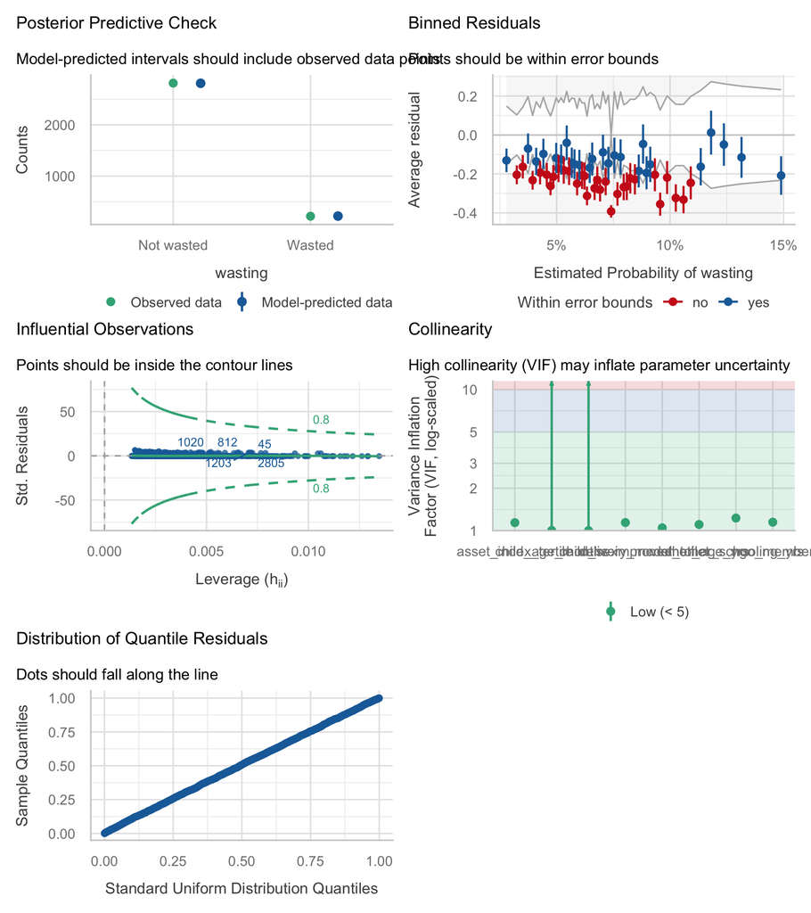

Variance inflation factors

| Term | VIF |
| --- | --- |
| delivery_model | 1.14 |
| child_sex | 1.00 |
| child_age_months | 1.00 |
| mother_age_yrs | 1.11 |
| mother_schooling_yrs | 1.23 |
| asset_index_tertile | 1.14 |
| ngo_member | 1.15 |
| improved_toilet | 1.05 |

For a logistic model only some panels apply; homogeneity of variance and normality of residuals do not and should be ignored.

*Binned residuals* is the panel that matters and this model performs worst of the three binary outcomes on it: only 45% of bins lie inside the error bounds, against a nominal 95%. Refitting with quadratic terms for child age, mother’s age and schooling leaves it at 45% and worsens AIC (1562.2 versus 1557.0), so the problem is not a wrong functional form. Two things are contributing: the small number of events (218) means each bin holds only a handful of wasted children, so the binned average is noisy; and the clustering described under limitations produces genuine extra-binomial variation. The specification is retained and the caveat reported.

*Collinearity* is unproblematic as specified, all VIFs under 1.3 — but only because `sub_district` was deliberately excluded. The *posterior predictive check* reproduces the observed outcome distribution, and no observation lies outside the Cook’s-distance contours in the *influential observations* panel. With 24.2 events per parameter the model avoids the sparse-data regime, but the wide confidence intervals throughout Table 2 are the visible cost of having only 218 events.

# Discussion

7.2% of these rural Bangladeshi infants were wasted at 6-13 months. After mutual adjustment only two predictors retain an association: household wealth (highest versus lowest asset tertile) and the child’s age. The crude maternal-schooling association disappears once wealth is held constant, which is the clearest substantive finding here — acute undernutrition in this population tracks household resources rather than maternal education. How growth monitoring was delivered shows no association with wasting, before or after adjustment. The honest summary is that this survey has little to say about wasting: most of what determines whether a child is acutely thin — a recent diarrhoeal episode, a seasonal food gap, an interrupted feed — was not measured.

**Limitations.**

*Few events, so power is limited.* Only 218 of 3031 children were wasted. Almost every confidence interval in Table 2 is wide enough to contain both a clinically important effect and no effect at all, so “not significant” here should be read as “not informative”, not as “no association”. This is the single biggest constraint on the analysis.

*The outcome is truncated by design, so prevalence is understated.* The source paper states that children with severe stunting, wasting or underweight were excluded on ethical grounds so they could be referred for treatment. The shipped file nonetheless contains 26 children with weight-for-height below -3 and 203 with height-for-age below -3, so the exclusion was either incomplete or applied on a different criterion. For wasting this is the most damaging of all three outcomes: the excluded group is precisely the group being counted, so the 7.2% prevalence understates the true burden, the already small event count is smaller than it should be, and every odds ratio is attenuated toward 1.

*Clustering cannot be modelled.* Delivery model is an **area-level** exposure assigned to whole upazilas — six of them — and the survey sampled 60 community-clinic catchment areas as matched pairs. Children in the same catchment share fieldworkers, scales, clinics, water supply and food markets, so their outcomes are correlated; wasting in particular is driven by local, seasonal conditions that operate at exactly the catchment level. The file contains no clinic or cluster identifier, so neither random effects nor cluster-robust standard errors can be fitted, and the confidence interval on `delivery_model` is too narrow. `sub_district` cannot substitute as a cluster variable because it is collinear with the exposure.

*Age definition is inconsistent in the source.* The paper’s abstract says children “under one year”, its methods say 6-23 months, and the data run 6.0 to 13.0 months. We describe the observed range only.

*Design and residual confounding.* Cross-sectional data give associations, not effects. Wasting is the index most sensitive to *recent* events, and neither recent illness, feeding practice, nor season of measurement was recorded — a serious omission, since wasting in Bangladesh is strongly seasonal.

*Sparse and dropped variables.* `mother_occupation` and `religion_muslim` were excluded as near-constant; with 218 events, estimating anything about either would be reckless.

**Future work.** Repeated measurement across seasons, with cluster identifiers and recent-illness histories, and without the severe-malnutrition exclusion, would be needed before this dataset could say anything useful about acute undernutrition.

# Feasibility notes

*Not part of a student report.*

**Verdict: the weakest of the six outcomes. Usable, but only just, and a student who picks it should be warned what they are signing up for.**

1. **Only 218 events.** Events per parameter is 24.2 — above the rule-of-thumb 10, so nothing breaks, but the model is underpowered and most of the report will consist of non-significant results with wide intervals. Students often read that as failure.
2. **Only two significant adjusted predictors** (highest asset tertile and child age). The “which predictors survive adjustment” discussion is very short.
3. **On the other hand, there is exactly one good teaching moment**: maternal schooling loses significance on adjustment (0.958, p = 0.029 to 0.980, p = 0.358), a 53% attenuation on the log-odds scale, and the mechanism (wealth confounding) is easy to explain. If the assignment is graded on the confounding narrative rather than on the number of findings, this is salvageable.
4. **Worst binned residuals of the six models** (45% of bins inside bounds). Quadratic terms do not help and make AIC worse. Students must be told to attribute this to sparse events plus clustering, not to hunt for transformations.
5. **The outcome must be derived**, and the `<=` versus `<` convention changes the event count from 218 to
   215. The brief must state the intended cut.
6. **`weight_for_height_z` must never appear as a predictor** — it defines the outcome and gives complete separation. `weight_for_age_z` shares the same weight measurement and is nearly as bad.
7. **`delivery_model` versus `sub_district`.** 99.7% overlap (8 discordant records out of 3038); together, VIFs of roughly 96 and 103.
8. **Near-constant predictors.** Sensitivity fit adding them back — note how much worse the intervals are here than in the other outcomes, because there are so few events:

Near-constant predictors, added back (odds ratios)

8 wasted children among 77 non-housewives; 2 among 66 non-Muslim households

| term | estimate | conf.low | conf.high | p.value |
| --- | --- | --- | --- | --- |
| mother_occupationOther | 1.666 | 0.716 | 3.404 | 0.194 |
| religion_muslimMuslim | 2.632 | 0.811 | 16.160 | 0.181 |

Two wasted children in the entire non-Muslim group. Nothing here is interpretable.

9. **Overlap with `weight_for_height_z`.** Same measurement, dichotomised, and the continuous version has far more power. If a student is set on acute undernutrition, push them to the Z-score.